# R Notebook

##################PART A##################

produce part-utilities table

```r
load("GBA424 - Toy Horse Case Data.RData")
df<-data.frame(c(1:200))
for (i in 1:length(unique(conjointData$ID))){
  reg<-lm(ratings~factor(price)+factor(size)+factor(motion)+factor(style), data=conjointData[conjointData$ID==i,],na.action = na.omit)
  df[i,2:6]<-reg$coefficients
}
colnames(df)<-c("ID","Intercept","Price119.99","26inches","Rocking","Glamour")
df
```

| ID | Intercept | Price119.99 | 26inches | Rocking | Glamour |
| --- | --- | --- | --- | --- | --- |
| 1 | 42.16541 | 8.600463 | 21.33443196 | 6.289641 | 1.181536e+01 |
| 2 | 40.17178 | 13.059091 | -10.75051993 | 15.780864 | -3.018138e+00 |
| 3 | 51.99862 | 7.226711 | 14.05147057 | 6.034665 | 7.448577e+00 |
| 4 | 49.05301 | 9.573213 | 19.27094748 | 4.736483 | 5.486421e+00 |
| 5 | 27.91527 | 24.186384 | 5.22247553 | -6.705663 | -6.788886e+00 |
| 6 | 40.24820 | 17.932998 | -8.15160787 | 9.765526 | 1.537888e-01 |
| 7 | 44.26003 | 10.239404 | 16.89381882 | 4.479289 | 1.631098e+01 |
| 8 | 36.96537 | 20.817452 | 4.68799262 | -12.169797 | -9.406489e+00 |
| 9 | 32.63474 | 23.824031 | 8.36673011 | -13.439713 | -8.300307e+00 |
| 10 | 33.73801 | 19.486133 | 4.29827953 | -11.592532 | -7.739851e+00 |

[output cut: 190 more lines]

produce predictions for missing profiles

```r
reg<-lm(ratings~factor(price)+factor(size)+factor(motion)+factor(style), data=conjointData[conjointData$ID==1,],na.action = na.omit)
df_fill<-conjointData[conjointData$ID==1,]
pred<-predict(reg,df_fill[rowSums(is.na(df_fill))>0,][,4:7])
df_fill[rowSums(is.na(df_fill))>0,]$ratings<-pred
for (i in 2:length(unique(conjointData$ID))){
  reg<-lm(ratings~factor(price)+factor(size)+factor(motion)+factor(style), data=conjointData[conjointData$ID==i,],na.action = na.omit)
  df_fill_new<-conjointData[conjointData$ID==i,]
  pred<-predict(reg,df_fill_new[rowSums(is.na(df_fill_new))>0,][,4:7])
  df_fill_new[rowSums(is.na(df_fill_new))>0,]$ratings<-pred
  df_fill<-rbind(df_fill,df_fill_new)
}
df_fill
```

|  | ID | profile | ratings | price | size | motion | style |
| --- | --- | --- | --- | --- | --- | --- | --- |
| 1 | 1 | 1 | 44.637389 | 0 | 0 | 0 | 0 |
| 2 | 1 | 2 | 45.974420 | 1 | 0 | 0 | 0 |
| 3 | 1 | 3 | 63.499840 | 0 | 1 | 0 | 0 |
| 4 | 1 | 4 | 75.389100 | 1 | 1 | 0 | 0 |
| 5 | 1 | 5 | 43.213655 | 0 | 0 | 1 | 0 |
| 6 | 1 | 6 | 57.055512 | 1 | 0 | 1 | 0 |
| 7 | 1 | 7 | 73.575588 | 0 | 1 | 1 | 0 |
| 8 | 1 | 8 | 78.875905 | 1 | 1 | 1 | 0 |
| 9 | 1 | 9 | 61.865443 | 0 | 0 | 0 | 1 |
| 10 | 1 | 10 | 62.581230 | 1 | 0 | 0 | 1 |

[output cut: 3190 more lines]

##################PART B##################

Evaluate number of clusters to use on data with visualizations Arguments: toClust, the data to do kmeans cluster analysis maxClusts=15, the max number of clusters to consider seed, the random number to initialize the clusters iter.max, the max iterations for clustering algorithms to use nstart, the number of starting points to consider Results: a list of weighted sum of squares and the pamk output including optimal number of clusters (nc) to create visualizations need to print tmp

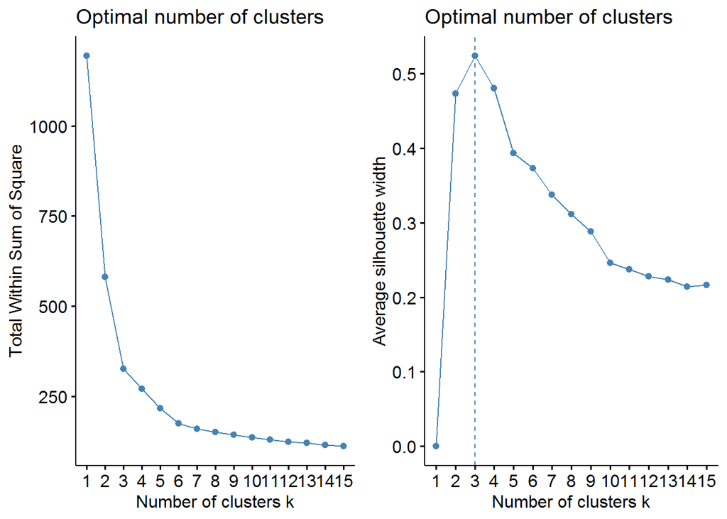

```
## $wss
##  [1] 1194.0000  581.7736  325.5614  270.7125  216.0992  174.4129  160.4724
##  [8]  150.4516  142.7567  135.7415  130.1458  123.2122  120.0139  116.1278
## [15]  109.5041
##
## $pm1
## [1] 3
##
## $gpw
```

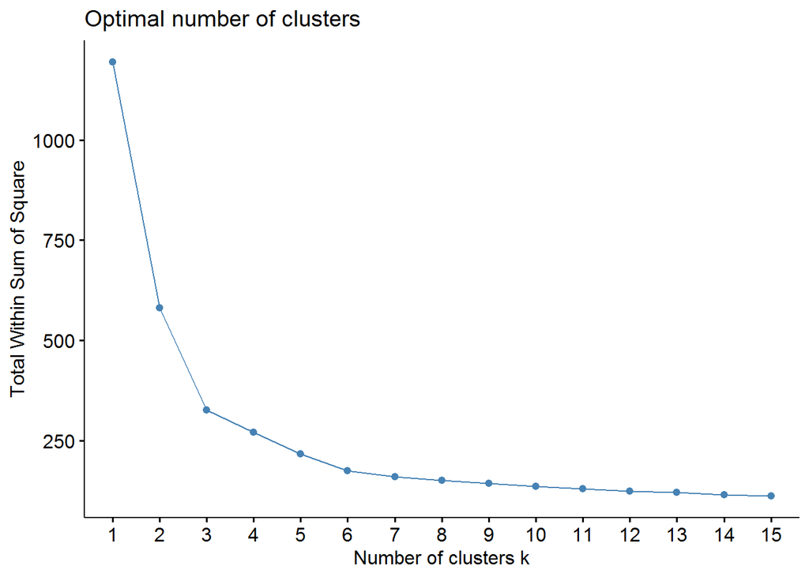

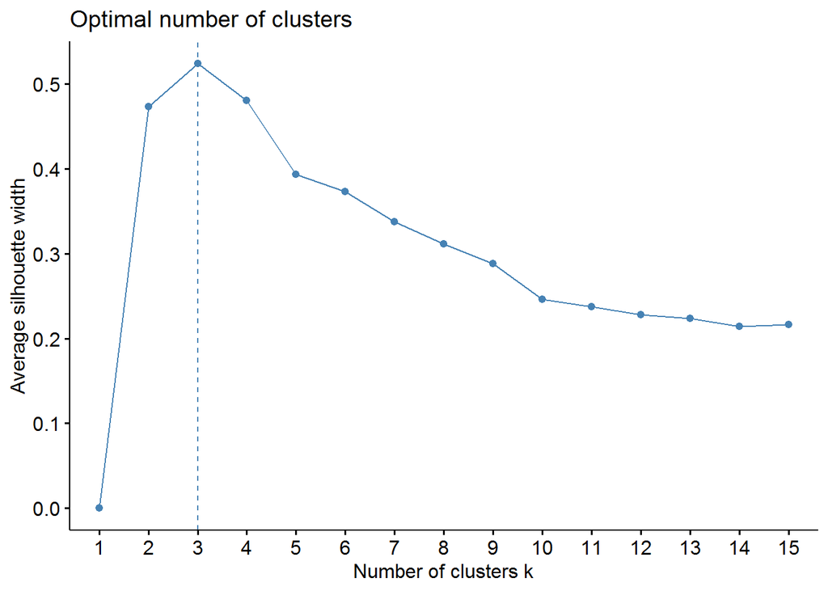

```r
library(ggplot2)
library(cluster)
library(fpc)
library(factoextra)
library(gridExtra)

clustTest = function(toClust,print=TRUE,scale=TRUE,maxClusts=15,seed=12345,nstart=20,iter.max=100){
  if(scale){ toClust = scale(toClust);}
  set.seed(seed);
  wss <- (nrow(toClust)-1)*sum(apply(toClust,2,var))
  for (i in 2:maxClusts) wss[i] <- sum(kmeans(toClust,centers=i,nstart=nstart,iter.max=iter.max)$withinss)
  gpw = fviz_nbclust(toClust,kmeans,method="wss",iter.max=iter.max,nstart=nstart,k.max=maxClusts) #alternative way to get wss elbow chart.
  pm1 = pamk(toClust,scaling=TRUE)
  gps = fviz_nbclust(toClust,kmeans,method="silhouette",iter.max=iter.max,nstart=nstart,k.max=maxClusts)
  if(print){
    grid.arrange(gpw,gps, nrow = 1)
  }
  list(wss=wss,pm1=pm1$nc,gpw=gpw,gps=gps)
}

clustTest(df,print=TRUE,scale=TRUE,maxClusts=15,seed=12345,nstart=20,iter.max=100) #our optimal clusters number is 3
```

Runs a set of clusters as kmeans Arguments: toClust, data.frame with data to cluster nClusts, vector of number of clusters, each run as separate kmeans … some additional arguments to be passed to clusters Return: list of kms, kmeans cluster output with length of nClusts ps, list of plots of the clusters against first 2 principle components

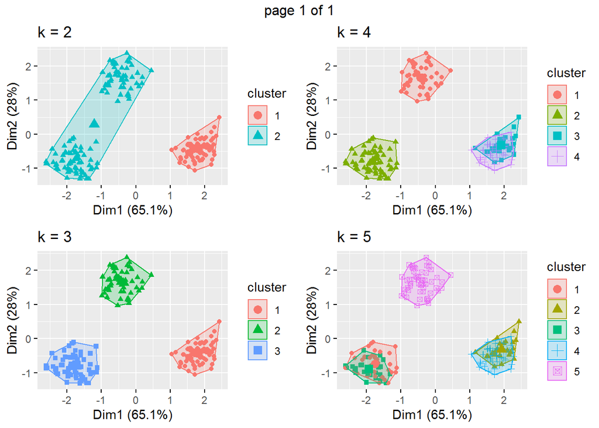

```r
runClusts = function(toClust,nClusts,print=TRUE,maxClusts=15,seed=12345,nstart=20,iter.max=100){
  if(length(nClusts)>4){
    warning("Using only first 4 elements of nClusts.")
  }
  kms=list(); ps=list();
  for(i in 1:length(nClusts)){
    kms[[i]] = kmeans(toClust,nClusts[i],iter.max = iter.max, nstart=nstart)
    ps[[i]] = fviz_cluster(kms[[i]], geom = "point", data = toClust) + ggtitle(paste("k =",nClusts[i]))

  }
  library(gridExtra)
  if(print){
    tmp = marrangeGrob(ps, nrow = 2,ncol=2)
    print(tmp)
  }
  list(kms=kms,ps=ps)
}
clusts = runClusts(df[,3:6],c(2,3,4,5),print=TRUE,maxClusts=15,seed=12345,nstart=20,iter.max=100)
```